# COMPSCIX 415.2 Homework 6

Chisun Fan

March 11, 2019

## Exercise 1

Load the Whickham dataset (data(Whickham)). You will need to load the mosaicData package first, but I also included the data as a csv file on Canvas if you would rather download it there and load it with the readr package. Look at the help file on this dataset to learn a bit about it. Note that the help file only exists if you are using the dataset from the mosaicData package. If you are loading the dataset from the csv file, do a Google search of this dataset and package name to help answer the first two questions below.

### 1. What variables are in this data set?

**outcome, smoker, and age are the variables.**

### 2. How many observations are there and what does each represent?

**1314**

### 3. Create a table (use the R code below as a guide) and a visualization of the relationship between smoking status and outcome, ignoring age. What do you see? Does it make sense?

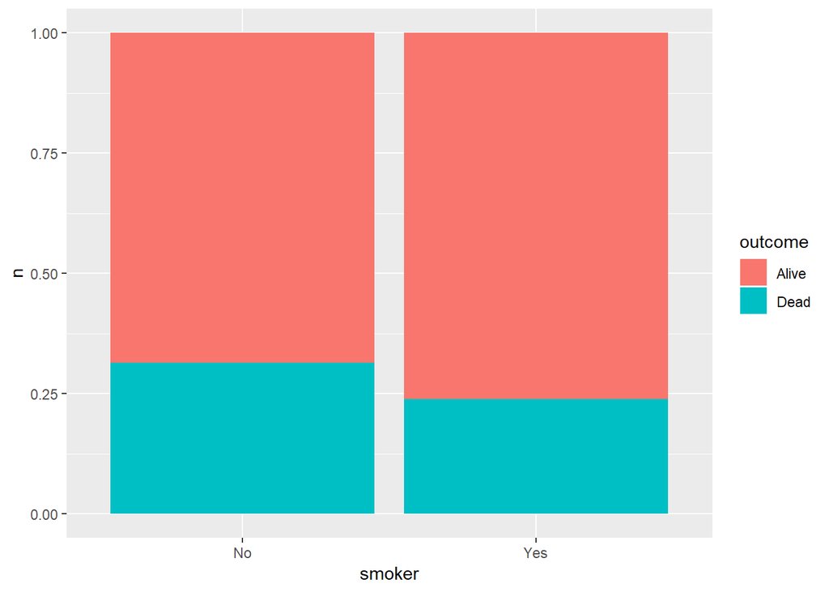

```r
library(mosaicData)
library(tidyverse)
Whickham %>% count(smoker,outcome) %>% ggplot()+geom_bar(mapping=aes(x=smoker,y=n,fill=outcome),stat='identity', position = 'fill')
```

**It appears the death rate is higher for non-smokers which does not make any sense**

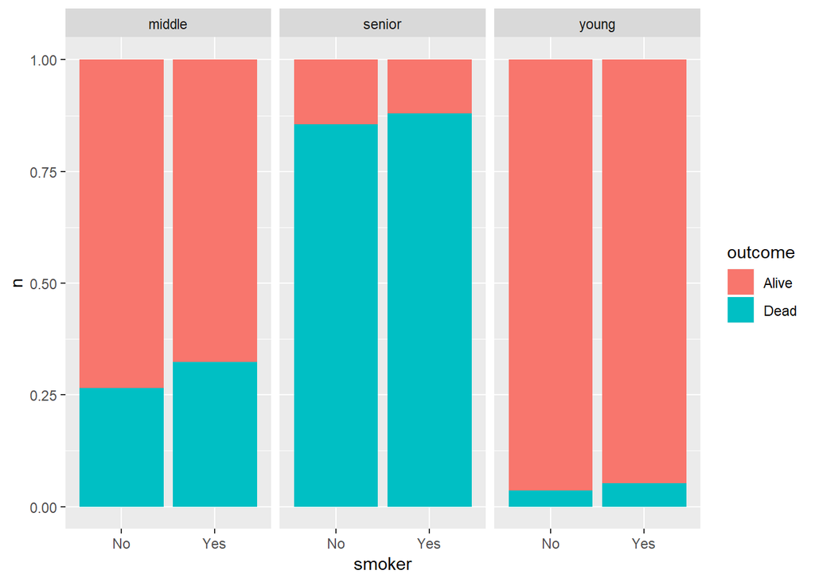

```r
smokers_age <- Whickham %>% mutate(age_group =                  case_when(age <= 44 ~ 'young',                                          age>44 & age <= 64 ~ 'middle',                                age > 64 ~ 'senior'))
 smokers_age %>% count(smoker,outcome,age_group) %>% ggplot()+geom_bar(aes(x=smoker,y=n,fill=outcome),stat='identity', position = 'fill')+facet_grid(~age_group)
```

**for each age group, the death rate is always higher for smokers, which makes more sense now.**

## Exercise 2

The Central Limit Theorem states that the sampling distribution of sample means is approximately Normal, regardless of the distribution of your population. For this exercise our population distribution will be a Gamma(1,2) distribution, and we’ll show that the sampling distribution of the mean is in fact normally distributed.

### 1. Generate a random sample of size n = 10000 from a gamma(1,2) distribution and plot a histogram or density curve. Use the code below to help you get your sample.

library(tidyverse) n <- 10000 look at ?rgamma to read about this function gamma_samp <- tibble(x = rgamma(n, shape = 1, scale = 2))

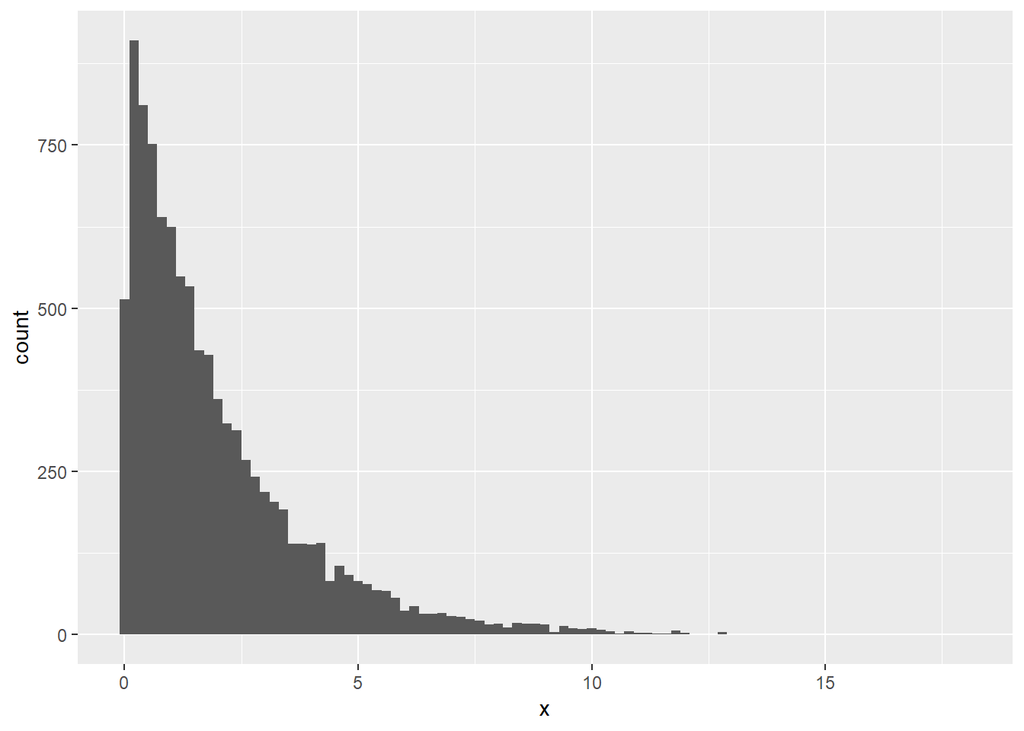

```r
library(tidyverse)
n <- 10000
gamma_samp <- tibble(x = rgamma(n, shape = 1, scale = 2))
gamma_samp %>% ggplot()+geom_histogram(mapping = aes(x=x),binwidth = 0.2)
```

### 2. What is the mean and standard deviation of your sample? They should both be close to 2 because for a gamma distribution:2 mean = shape x scale variance = shape x scaleˆ2 mean_samp <- gamma_samp %>% .[[‘x’]] %>% mean()

```r
gamma_samp %>%  summarise(average = mean(x), stdev = sd(x))
```

```
## # A tibble: 1 x 2
##   average stdev
##     <dbl> <dbl>
## 1    1.98  1.98
```

**mean and standard deviation are close to 2**

### 3. Pretend the distribution of our population of data looks like the plot above. Now take a sample of size n = 30 from a Gamma(1,2) distribution, plot the histogram or density curve, and calculate the mean and standard deviation.

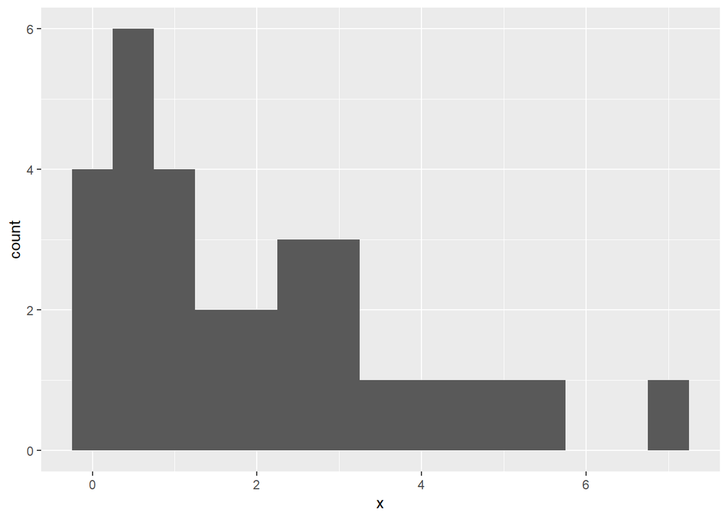

```r
gamma_samp <- tibble(x=rgamma(30, shape=1, scale=2))
gamma_samp  %>% ggplot()+geom_histogram(mapping=aes(x=x),binwidth=0.5)
```

```r
gamma_samp %>% summarise(mean=mean(x),stddev=sd(x))
```

```
## # A tibble: 1 x 2
##    mean stddev
##   <dbl>  <dbl>
## 1  2.02   1.81
```

### 4. Take a sample of size n = 30, again from the Gamma(1,2) distribution, calculate the mean, and assign it to a vector named mean_samp. Repeat this 10000 times!!!! The code below might help.

# create a vector with 10000 NAs

mean_samp <- rep(NA, 10000) # start a loop for(i in 1:10000) { g_samp <- rgamma(30, shape = 1, scale = 2) mean_samp[i] <- mean(g_samp) } # Convert vector to a tibble mean_samp <- tibble(mean_samp) ***

```r
mean_samp <- rep(NA, 10000)
for(i in 1:10000) {
g_samp <- rgamma(30, shape = 1, scale = 2)
mean_samp[i] <- mean(g_samp)
}
mean_samp <- tibble(mean_samp)
```

### 5. Make a histogram of your collection of means from above (mean_samp).

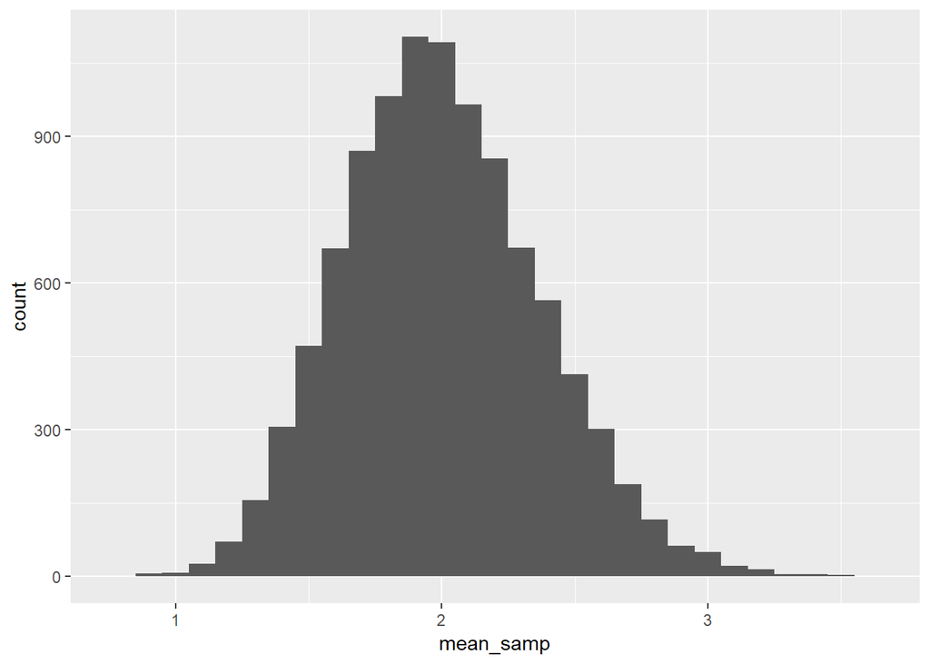

```r
mean_samp %>% ggplot()+geom_histogram(mapping=aes(x=mean_samp),binwidth=0.1)
```

### 6. Calculate the mean and standard deviation of all of your sample means.

```r
mean_samp %>% summarise(mean=mean(mean_samp),stddev=sd(mean_samp))
```

```
## # A tibble: 1 x 2
##    mean stddev
##   <dbl>  <dbl>
## 1  2.00  0.370
```

### 7. Did anything surprise you about your answers to #6?

**No surprise. The answers is close to what was expected.**

### 8. According to the Central Limit Theorem, the mean of your sampling distribution should be very close to 2, and the standard deviation of your sampling distribution should be close to σ/n = 2/sqrt(30) = 0.365.Repeat #4-#6, but now with a sample of size n = 300 instead. Do your results match up well with the theorem?

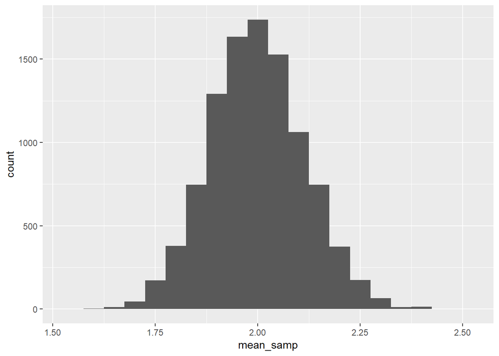

```r
mean_samp <- rep(NA, 10000)
for(i in 1:10000) {
g_samp <- rgamma(300, shape = 1, scale = 2)
mean_samp[i] <- mean(g_samp)
}
mean_samp <- tibble(mean_samp)

mean_samp %>% ggplot()+geom_histogram(mapping=aes(x=mean_samp),binwidth=0.05)
```

```r
mean_samp %>% summarise(mean=mean(mean_samp),stddev=sd(mean_samp))
```

```
## # A tibble: 1 x 2
##    mean stddev
##   <dbl>  <dbl>
## 1  2.00  0.114
```

**the standard error is 2/sqrt(300) ~.114 which is close to output of the calculation**